# R Notebook to summarize the solutions for the extra exercises of R-Tutor

You can find the original tutorials here: http://www.r-tutor.com/elementary-statistics

# Qualitative Data

## Frequency Distribution of Qualitative Data

http://www.r-tutor.com/elementary-statistics/qualitative-data/frequency-distribution-qualitative-data

```r
library(MASS)
head(painters)
```

|  | Composition | Drawing | Colour | Expression | School |
| --- | --- | --- | --- | --- | --- |
| Da Udine | 10 | 8 | 16 | 3 | A |
| Da Vinci | 15 | 16 | 4 | 14 | A |
| Del Piombo | 8 | 13 | 16 | 7 | A |
| Del Sarto | 12 | 16 | 9 | 8 | A |
| Fr. Penni | 0 | 15 | 8 | 0 | A |
| Guilio Romano | 15 | 16 | 4 | 14 | A |

```r
NA
```

1. Find the frequency distribution of the composition scores in painters.

```r
composition = painters$Composition
composition.freq = table(composition)
cbind(composition.freq)
```

```
   composition.freq
0                 1
4                 3
5                 1
6                 3
8                 6
9                 1
10                6
11                2
12                4
13                5
14                3
15               14
16                2
17                1
18                2
```

```r
school = painters$School
school.freq = table(school)
most_painters = max(school.freq)
most_painters
```

```
[1] 10
```

## Relative Frequency Distribution of Qualitative Data

http://www.r-tutor.com/elementary-statistics/qualitative-data/relative-frequency-distribution-qualitative-data

1. Find the relative frequency distribution of the composition scores in painters.

```r
old=options(digits = 1) #setting significant digits to 1

composition.relfreq = composition.freq / nrow(painters)
cbind(composition.relfreq)
```

```
   composition.relfreq
0                 0.02
4                 0.06
5                 0.02
6                 0.06
8                 0.11
9                 0.02
10                0.11
11                0.04
12                0.07
13                0.09
14                0.06
15                0.26
16                0.04
17                0.02
18                0.04
```

```r
options(old) #resetting old settings
```

## Bar Graph

http://www.r-tutor.com/elementary-statistics/qualitative-data/bar-graph

```r
colors = c("red", "yellow", "green", "violet", "orange", "blue", "pink", "cyan")
```

1. Find the bar graph of the composition scores in painters.

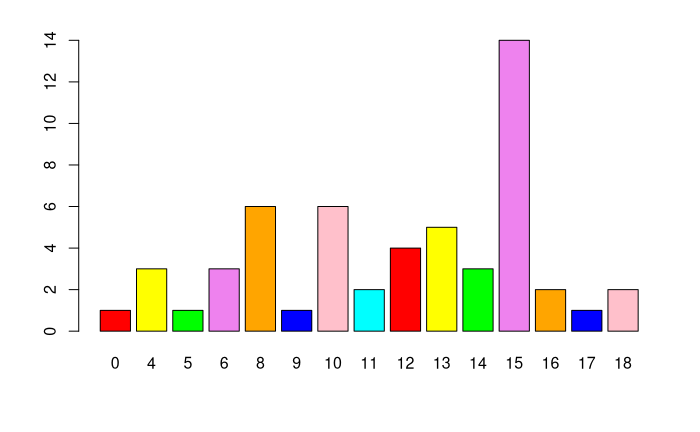

```r
barplot(composition.freq, col = colors)
```

## Pie Chart

http://www.r-tutor.com/elementary-statistics/qualitative-data/pie-chart

1. Find the pie chart of the composition scores in painters.

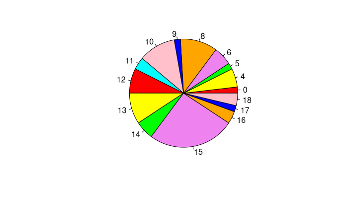

```r
pie(composition.freq, col = colors)
```

## Category Statistics

http://www.r-tutor.com/elementary-statistics/qualitative-data/category-statistics

```r
school = painters$School
c_school = school == "C"
c_painters = painters[c_school, ]  # child data set
mean(c_painters$Composition)
```

```
[1] 13.16667
```

```r
tapply(painters$Composition, painters$School, mean)
```

```
       A        B        C        D        E        F        G        H
10.40000 12.16667 13.16667  9.10000 13.57143  7.25000 13.85714 14.00000
```

1. Find programmatically the school with the highest composition scores.

```r
max_comp = tapply(painters$Composition, painters$School, max)
max_comp[which(max_comp %in% c(max(max_comp)))]
```

```
 E  G
18 18
```

2. Find the percentage of painters whose color score is equal to or above 14.

```r
above14 = sum(painters$Colour >= 14)
all_painters = nrow(painters)

perc = above14 / all_painters * 100
sprintf("Painters with a Colour Score above 14: %.2f %%", perc)
```

```
[1] "Painters with a Colour Score above 14: 37.04 %"
```

# Quantitative Data

```r
head(faithful)
```

|  | eruptions | waiting |
| --- | --- | --- |
| 1 | 3.600 | 79 |
| 2 | 1.800 | 54 |
| 3 | 3.333 | 74 |
| 4 | 2.283 | 62 |
| 5 | 4.533 | 85 |
| 6 | 2.883 | 55 |

## Frequency Distribution of Quantitative Data

1. Find the frequency distribution of the eruption waiting periods in faithful.

```r
waits = faithful$waiting
# range(waits) # min = 43; max = 96
wbreaks = seq(40, 100, by = 5)
waits.cut = cut(waits, wbreaks, right = FALSE)
waits.freq = table(waits.cut)
cbind(waits.freq)
```

```
         waits.freq
[40,45)           1
[45,50)          20
[50,55)          32
[55,60)          24
[60,65)          17
[65,70)           9
[70,75)          23
[75,80)          54
[80,85)          57
[85,90)          23
[90,95)          11
[95,100)          1
```

2. Find programmatically the duration sub-interval that has the most eruptions.

```r
head(duration.freq[order(-duration.freq)],1)
```

```
duration.cut
[4,4.5)
     73
```

## Histogram

```r
colors = c("red", "yellow", "green", "violet", "orange", "blue", "pink", "cyan")
```

1. Find the histogram of the eruption waiting period in faithful.

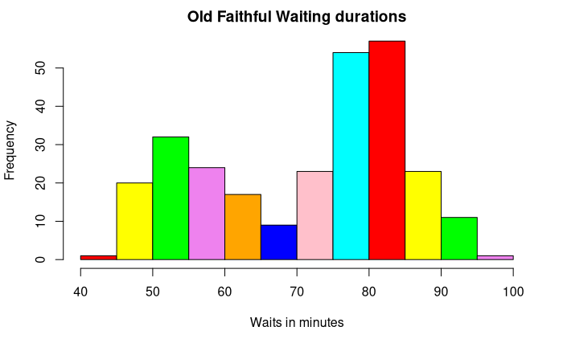

```r
hist(waits, right = FALSE, col = colors, main = "Old Faithful Waiting durations", xlab = "Waits in minutes")
```

## Relative Frequency Distribution of Quantitative Data

1. Find the relative frequency distribution of the eruption waiting periods in faithful.

```r
old = options(digits = 1)

waits.relfreq = waits.freq / nrow(faithful)
#waits.relfreq
cbind(waits.freq, waits.relfreq)
```

```
         waits.freq waits.relfreq
[40,45)           1         0.004
[45,50)          20         0.074
[50,55)          32         0.118
[55,60)          24         0.088
[60,65)          17         0.062
[65,70)           9         0.033
[70,75)          23         0.085
[75,80)          54         0.199
[80,85)          57         0.210
[85,90)          23         0.085
[90,95)          11         0.040
[95,100)          1         0.004
```

```r
options(old)
```

## Cumulative Frequency Distribution

https://www.r-tutor.com/elementary-statistics/quantitative-data/cumulative-frequency-distribution

1. Find the cumulative frequency distribution of the eruption waiting periods in faithful.

```r
waits.cumfreq = cumsum(waits.freq)
cbind(waits.freq, waits.cumfreq)
```

```
         waits.freq waits.cumfreq
[40,45)           1             1
[45,50)          20            21
[50,55)          32            53
[55,60)          24            77
[60,65)          17            94
[65,70)           9           103
[70,75)          23           126
[75,80)          54           180
[80,85)          57           237
[85,90)          23           260
[90,95)          11           271
[95,100)          1           272
```

## Cumulative Frequency Graph

1. Find the cumulative frequency graph of the eruption waiting periods in faithful.

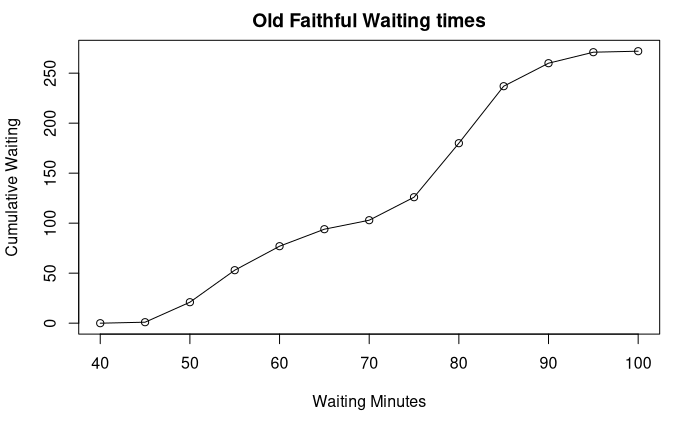

```r
cumfreq0_w = c(0, waits.cumfreq)
plot(wbreaks, cumfreq0_w, main = "Old Faithful Waiting times", xlab = "Waiting Minutes", ylab = "Cumulative Waiting")
lines(wbreaks,cumfreq0_w)
```

## Cumulative Relative Frequency Distribution

1. Find the cumulative frequency distribution of the eruption waiting periods in faithful.

```r
old = options(digits = 2)

waits.cumrelfreq = waits.cumfreq / nrow(faithful)
cbind(waits.cumfreq, waits.cumrelfreq)
```

```
         waits.cumfreq waits.cumrelfreq
[40,45)              1           0.0037
[45,50)             21           0.0772
[50,55)             53           0.1949
[55,60)             77           0.2831
[60,65)             94           0.3456
[65,70)            103           0.3787
[70,75)            126           0.4632
[75,80)            180           0.6618
[80,85)            237           0.8713
[85,90)            260           0.9559
[90,95)            271           0.9963
[95,100)           272           1.0000
```

```r
options(old)
```

## Cumulative Relative Frequency Graph

1. Find the cumulative relative frequency graph of the eruption waiting periods in faithful.

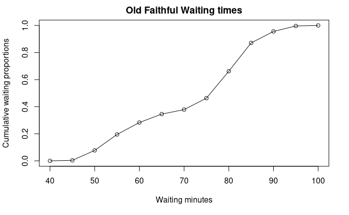

```r
cumrelfreq0_w = c(0, waits.cumrelfreq)
plot(wbreaks, cumrelfreq0_w, main = "Old Faithful Waiting times", xlab = "Waiting minutes", ylab = "Cumulative waiting proportions")
lines(wbreaks, cumrelfreq0_w)
```

Alternatively:

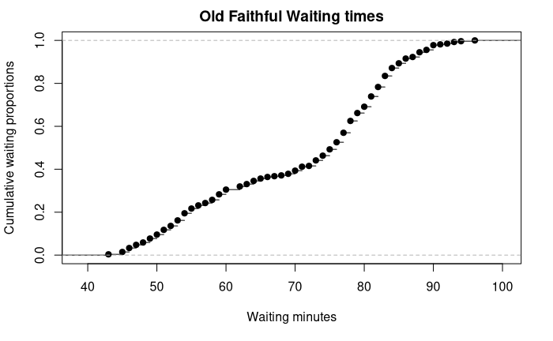

```r
Fn_w = ecdf(waits)
plot(Fn_w, main = "Old Faithful Waiting times", xlab = "Waiting minutes", ylab = "Cumulative waiting proportions")
```

## Stem-and-Leaf Plot

1. Find the stem-and-leaf plot of the eruption waiting periods in faithful.

```r
stem(waits)
```

```
  The decimal point is 1 digit(s) to the right of the |

  4 | 3
  4 | 55566666777788899999
  5 | 00000111111222223333333444444444
  5 | 555555666677788889999999
  6 | 00000022223334444
  6 | 555667899
  7 | 00001111123333333444444
  7 | 555555556666666667777777777778888888888888889999999999
  8 | 000000001111111111111222222222222333333333333334444444444
  8 | 55555566666677888888999
  9 | 00000012334
  9 | 6
```

## Scatter Plot

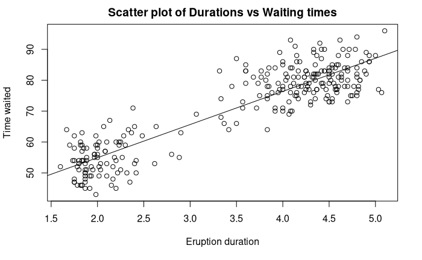

```r
plot(duration, waits, xlab = "Eruption duration", ylab = "Time waited", main = "Scatter plot of Durations vs Waiting times")
abline(lm(waits ~ duration))
```

# Numerical Measures

http://www.r-tutor.com/elementary-statistics/numerical-measures

1. Find the mean eruption waiting periods in faithful.

```r
mean(waits)
```

```
[1] 70.89706
```

## Median

```r
median(waits)
```

```
[1] 76
```

## Quartile

1. Find the quartiles of the eruption waiting periods in faithful.

```r
quantile(waits)
```

```
  0%  25%  50%  75% 100%
  43   58   76   82   96
```

## Percentile

```r
quantile(waits, c(.17, .43, .67, .85))
```

```
17% 43% 67% 85%
 54  73  80  84
```

## Range

1. Find the range of the eruption waiting periods in faithful.

```r
max(waits) - min(waits)
```

```
[1] 53
```

## Interquartile Range

1. Find the interquartile range of eruption waiting periods in faithful.

```r
IQR(waits)
```

```
[1] 24
```

## Box Plot

1. Find the box plot of the eruption waiting periods in faithful.

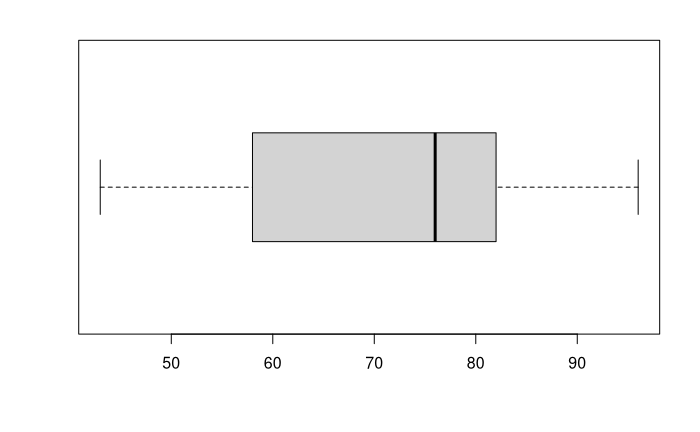

```r
boxplot(waits, horizontal = TRUE)
```

## Variance

1. Find the variance of the eruption waiting periods in faithful.

```r
var(waits)
```

```
[1] 184.8233
```

## Standard Deviation

1. Find the standard deviation of the eruption waiting periods in faithful.

```r
sd(waits)
```

```
[1] 13.59497
```

## Covariance

```r
cov(duration, waits)
```

```
[1] 13.97781
```

## Correlation Coefficient

```r
cor(duration, waits)
```

```
[1] 0.9008112
```

## Central Moment

```r
# install.package("moments")
```

1. Find the third central moment of eruption waiting period in faithful.

```r
library(moments)
moment(waits, order = 3, central = TRUE)
```

```
[1] -1040.307
```

## Skewness

1. Find the skewness of eruption waiting period in faithful.

```r
skewness(waits)
```

```
[1] -0.4163188
```

## Kurtosis

1. Find the excess kurtosis of eruption waiting period in faithful.

```r
kurtosis(waits)
```

```
[1] -1.156263
```

# Probability Distributions

https://www.r-tutor.com/elementary-statistics/probability-distributions

```r
i=0
for (x in seq(0, 4)){i= i+ dbinom(x, size = 12, prob = 0.2)}
i
```

```
[1] 0.9274445
```

```r
pbinom(4, size = 12, prob = 0.2)
```

```
[1] 0.9274445
```

```r
ppois(16, lambda = 12)
```

```
[1] 0.898709
```

```r
ppois(16, lambda = 12, lower.tail = FALSE)
```

```
[1] 0.101291
```

```r
runif(10, min=1, max=3)
```

```
 [1] 1.714725 2.990951 1.094316 2.243596 1.886131 2.249435 2.492466 1.467587 1.263927
[10] 2.311076
```

```r
pexp(2, rate = 1/3)
```

```
[1] 0.4865829
```

```r
pnorm(84, mean = 72, sd = 15.2, lower.tail = FALSE)
```

```
[1] 0.2149176
```

```r
qchisq(.95, df = 7)
```

```
[1] 14.06714
```

```r
qt(c(.025, .975), df = 5)
```

```
[1] -2.570582  2.570582
```

```r
qf(.95, df1 = 5, df2 = 2)
```

```
[1] 19.29641
```

# Interval Estimation

http://www.r-tutor.com/elementary-statistics/interval-estimation

```r
library(MASS)
```